[← Volver a Día 3](https://valentinzarate.github.io/taller_mov/tema_3/tema3.html)

# RSF

# Selección de recursos

Cuando hablamos de análsis de selección estamos intentando ver dónde estuvo el animal en función de lo que tenía disponible. Es decir, si el animal usa un recurso o hábitat de manera desproporcional a su disponibildad. Los análisis de selección de recursos no consideran la trayectoria en si, sino dónde fue detectado el animal. Luego vamos a ver selección de pasos, dónde la selección esta explícitamente determinada por el movimiento del animal.

Una aclaración importante antes… selección no es lo mismo que uso (lo que vimos antes). Un ambiente puede ser muy usado simplemente porque es muy abundante. Y otro ambiente puede ser poco usado en términos absolutos, pero podría estar siendo seleccionado si es usado más de lo esperado dada su baja disponibilidad.

Analíticamente vamos a enfocarnos en dos cosas:

- **Uso:** los lugares donde efectivamente observamos al animal.
- **Disponibilidad:** los lugares que el animal podría haber usado, al menos dentro de una definición razonable del área disponible.

En términos simples:

**Selección = uso en relación con disponibilidad**

Esta comparación es la base de las **Resource Selection Functions**, o RSF. Estos modelos relacionan la probabilidad relativa de uso de un lugar con las características ambientales del paisaje potencialmente utilizado por el animal focal. Es decir, intentan vincular el patron de uso de ciertas covariables con la disponibilidad de las mismas (ej. pendiente, distancia al agua, cobertura vegetal o distancia a caminos).

Formalmente, las RSF producen valores proporcionales a la probabilidad de uso de una unidad de recurso. Por eso muchas veces se interpretan como superficies de *uso relativo* o *selección relativa* o *fuerza de selección*. En términos estadísticos los RSF se modelan como regresiones logísticas ponderadas por peso

$$Y_i \sim \text{Bernoulli}(p_i)$$

$$\text{logit}(p_i) =
\log\left(\frac{p_i}{1-p_i}\right)
=
\beta_0 + \beta_1 x_{1i} + \beta_2 x_{2i} + \cdots + \beta_k x_{ki}$$

donde $Y_i = 1$ indica una unidad usada y $Y_i = 0$ una unidad disponible o no usada, $p_i$ es la probabilidad relativa de uso, $x_{1i}, \ldots, x_{ki}$ son las covariables ambientales, y $\beta_1, \ldots, \beta_k$ representan la fuerza y dirección de la selección asociada a cada covariable.

La estimación se realiza maximizando una verosimilitud ponderada:

$$\ell_w(\boldsymbol{\beta}) =
\sum_{i=1}^{n}
w_i
\left[
Y_i \log(p_i) + (1-Y_i)\log(1-p_i)
\right]$$

donde $w_i$ es el peso asignado a la observación $i$. En el contexto de RSF, estos pesos suelen usarse para diferenciar las unidades usadas de las unidades disponibles, por ejemplo asignando pesos mayores a los puntos disponibles cuando estos representan una muestra del ambiente accesible.

### Trayectoria Simulada

Vamos a hacer una explicación guíada con scripts usando una trayectoria y un raster simulados. Trabajar con trayectorias simuladas a veces es bastante irreal, pero ayuda a trabajar con una dataset simple. Luego vamos a intentar abordar con MoveBank, el moco es que necesitamos algunos raster o capas vectoriales para hacer los RSF.

Vamos con el misma trayectoria y plot de antes

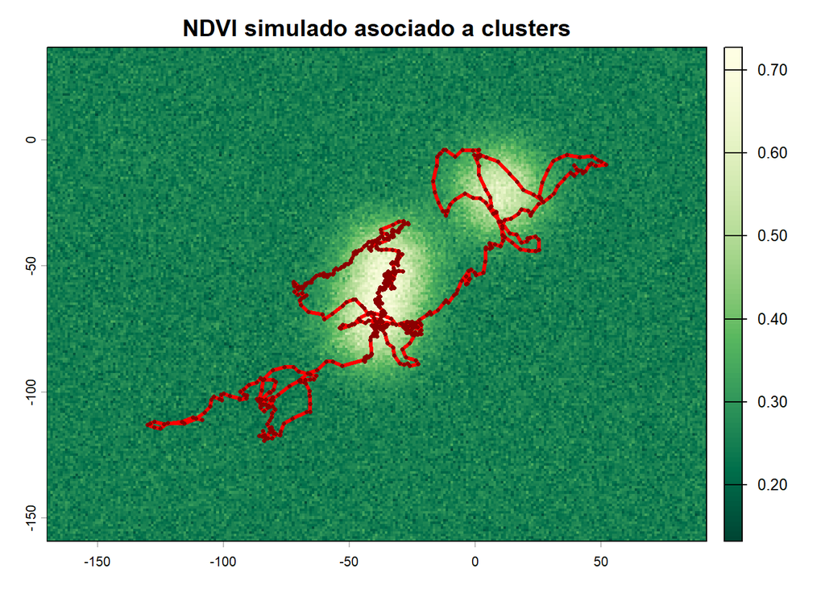

```r
plot(r,
     main = "NDVI simulado asociado a clusters",
     col = hcl.colors(100, "YlGn"))

lines(df$X, df$Y,
      col = "red",
      lwd = 3)

points(df$X, df$Y,
       pch = 16,
       cex = 0.5,
       col =  "darkred")
```

En esta trayectoria tenemos NDVI como capa ambiental. En un RSF típico una pregunta a responder sería: **¿el bicho está sobreutilizando sitios con NDVI alto en relación con la disponibilidad de NDVI en el paisaje?**

En esa pregunta el tiempo parece irrelevante. Y, en cierto sentido, sí: un RSF clásico no modela explícitamente la secuencia temporal de posiciones. No le importa si el animal llegó al punto actual desde el norte, desde el sur, si venía caminando rápido o lento, o si estaba en una fase de movimiento persistente. El RSF compara **lugares usados** contra **lugares disponibles**.

Pero… aunque la pregunta ecológica no use explícitamente el tiempo, los datos sí vienen de una trayectoria. Y una trayectoria casi siempre tiene autocorrelación temporal.

## Puntos Independientes

Supongamos que tenemos una serie de posiciones GPS:

$$Z_1, Z_2, Z_3, ..., Z_n$$

donde cada posición puede escribirse como un número complejo:

$$Z_t = X_t + iY_t$$

En una trayectoria realista, posiciones cercanas en el tiempo tienden a estar cerca en el espacio. Es decir, si conocemos dónde estaba el animal a las 10:00, tenemos bastante información sobre dónde probablemente estaba a las 09:00. Matemáticamente, eso quiere decir que:

$$Z_t \not\perp Z_{t-1}$$

o, dicho de otra forma, en términos de correlación para los componentes que hacen a $Z_t$:

$$\operatorname{Cor}(X_t, X_{t-k}) > 0
\quad \text{y/o} \quad
\operatorname{Cor}(Y_t, Y_{t-k}) > 0$$

para ciertos valores pequeños de *k*. Acá *k* es un desfase temporal: 1 hora, 2 horas, 3 horas, etc.

Esto genera un problema para el RSF clásico. Cuando ajustamos una regresión logística del tipo:

$$\text{usado} \sim \text{NDVI}$$

el modelo trata cada punto usado como si fuera una observación independiente, como en cualquier regresión logística sin autocorrelación predefinida. En términos estadísticos, está trabajando como si la verosimilitud pudiera escribirse como el producto de contribuciones independientes.

$$L(\beta) =
\prod_{i=1}^{n}
P(y_i \mid x_i; \beta)^{w_i}$$

donde *y<sub>i</sub>* indica si el punto fue usado o disponible, y *x<sub>i</sub>* puede ser NDVI, distancia al agua, pendiente u otra covariable ambiental.

Pero si las posiciones usadas vienen de una trayectoria muestreada por ejemplo cada una hora, muchas de esas posiciones no son realmente independientes. El modelo cree que tiene mucha más información de la que en realidad tiene.

**Nota:** si el modelo incorporase la autocorrelación la verosimilitud debería definirse como una distribución conjunta, no como una productoria de las contribuciones marginales.

$$L(\boldsymbol{\beta}, \boldsymbol{\theta}) =
P(\mathbf{y} \mid \mathbf{X}; \boldsymbol{\beta}, \boldsymbol{\theta})$$
Donde $θ$ representa parámetros de autocorrelación espacial o temporal.

## Autocorrelación y pseudorreplicación

El problema práctico es que una trayectoria con muchos fixes cercanos puede generar una falsa sensación de mucho tamaño muestral. Por ejemplo, si un animal permanece varias horas en un parche de NDVI alto, vamos a tener muchos puntos usados en ese mismo tipo de ambiente.

En otras palabras, el modelo podría interpretar eso como fuerte selección por NDVI alto. Pero quizás no son muchas decisiones independientes de selección, sino una sola visita prolongada al mismo parche. Lo cual comportamental y ecológicamente puede tener relevancia y sentido, pero estadísticamente puede ser un problema que genera sesgos en la interpretación… al menos en el contexto de los RSF.

Entonces, la autocorrelación puede producir:

- errores estándar demasiado chicos;
- valores de *p* demasiado optimistas;
- intervalos de confianza demasiado angostos;
- una sobreestimación de cuánta información real tenemos;
- y, a veces, una interpretación exagerada de la selección.

Por eso muchos análisis RSF clásicos recomiendan usar posiciones suficientemente separadas en el tiempo, o al menos evaluar la autocorrelación antes de ajustar el modelo.

### Estimación de τ

Ahora vamos a estimar la autocorrelación temporal de la trayectoria usando las coordenadas $X$ e $Y$. La idea es calcular cuánto se parecen las posiciones separadas por 1 hora, 2 horas, 3 horas, y así sucesivamente.

Como tenemos dos coordenadas, vamos a calcular la autocorrelación de $X$ y la autocorrelación de $Y$, y luego vamos a promediarlas. Esto nos da una medida simple de autocorrelación espacial en función del desfase temporal.

Después vamos a definir τ como el primer desfase temporal en el que la autocorrelación cae por debajo de un umbral. Un umbral común y útil es:

$$\frac{1}{e} \approx 0.37$$

Este valor se usa muchas veces como una escala característica de decaimiento de la autocorrelación. No significa que a partir de ahí la independencia sea perfecta, pero nos da una regla práctica para decidir cada cuánto remuestrear.

Veamos cada cuanto están separadas las localizaciones en promedio

```r
dt <- median(diff(df$t))

dt
```

```
## Time difference of 1 hours
```

Para estimar una escala simple de independencia temporal vamos a mirar la autocorrelación de la trayectoria. La autocorrelación mide cuánto se parece una serie a sí misma cuando la desplazamos en el tiempo.

En nuestro caso calculamos la autocorrelación de la coordenada `X` y de la coordenada `Y` por separado. Un `lag` de 1 compara posiciones separadas por un fix; un `lag` de 2 compara posiciones separadas por dos fixes; y así sucesivamente. Como nuestra trayectoria fue simulada con un fix por hora, un `lag` de 1 equivale a una hora, un `lag` de 2 equivale a dos horas, etc.

Luego promediamos la autocorrelación de `X` y la autocorrelación de `Y`. Este promedio, que llamamos `rho_xy`, nos da una medida simple de cuánto se parece la posición del animal a posiciones tomadas varias horas antes o después.

```r
acf_x <- acf(df$X,
             lag.max = 200,
             plot = FALSE)

acf_y <- acf(df$Y,
             lag.max = 200,
             plot = FALSE)

lags <- as.numeric(acf_x$lag)

rho_x <- as.numeric(acf_x$acf)
rho_y <- as.numeric(acf_y$acf)

rho_xy <- (rho_x + rho_y) / 2

acf_dat <- data.frame(
  lag = lags,
  rho_x = rho_x,
  rho_y = rho_y,
  rho_xy = rho_xy)

head(acf_dat)
```

|  | lag | rho_x | rho_y | rho_xy |
| --- | --- | --- | --- | --- |
| 1 | 0 | 1.0000000 | 1.0000000 | 1.0000000 |
| 2 | 1 | 0.9940136 | 0.9926388 | 0.9933262 |
| 3 | 2 | 0.9858928 | 0.9842099 | 0.9850513 |
| 4 | 3 | 0.9761275 | 0.9750192 | 0.9755733 |
| 5 | 4 | 0.9646017 | 0.9658717 | 0.9652367 |
| 6 | 5 | 0.9518516 | 0.9568611 | 0.9543563 |

La primera fila corresponde al `lag = 0`. En ese caso la autocorrelación siempre vale 1, porque estamos comparando la serie consigo misma sin desplazarla. Lo importante es mirar cómo cae la autocorrelación a medida que aumenta el lag.

Si la autocorrelación se mantiene alta durante muchos lags, quiere decir que las posiciones cercanas en el tiempo son muy parecidas entre sí. En ese caso, usar todos los puntos en un RSF puede generar pseudorreplicación: el modelo trata muchos puntos cercanos como si fueran observaciones independientes, aunque en realidad representan una misma visita prolongada o un mismo tramo de movimiento.

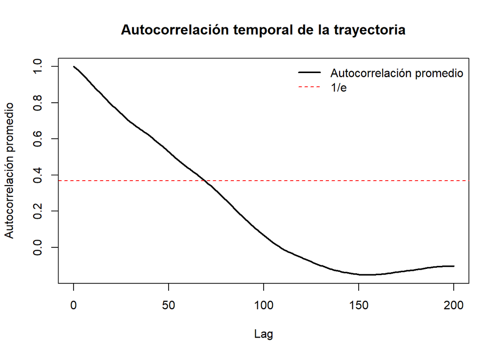

```r
plot(acf_dat$lag,
     acf_dat$rho_xy,
     type = "l",
     lwd = 2,
     xlab = "Lag",
     ylab = "Autocorrelación promedio",
     main = "Autocorrelación temporal de la trayectoria")

abline(h = 1 / exp(1),
       lty = 2,
       col = "red")

legend("topright",
       legend = c("Autocorrelación promedio", "1/e"),
       lty = c(1, 2),
       lwd = c(2, 1),
       col = c("black", "red"),
       bty = "n")
```

Ese “qué tan parecidas son” se define como una correlación entre la serie original y la misma serie desplazada en el tiempo.

Comparamos los valores de $X$ con los valores de $X$ desplazados $k$ pasos en el tiempo. Si los valores altos de $X$ tienden a estar seguidos por valores altos de $X$, y los valores bajos por valores bajos, la autocorrelación es positiva. Si no hay una relación clara, la autocorrelación se acerca a cero.

En este contexto, “parecidas” no quiere decir necesariamente que los puntos estén exactamente cerca en distancia euclidiana. Quiere decir que la coordenada mantiene memoria.

#### Cuándo son parecidas?

Acá hay algo variable, definir cuándo dos coordenadas sucesivas son parecidas es bastante relativo, y depende de cuán conservadores queremos ser.. un punto intermedio bastante usado es definir un umbral de *1 / exp(1)* que equivale a aproximadamente 0.367. En criollo quiere decir que: Vamos a considerar que la autocorrelación ya decayó bastante cuando baja por debajo de aproximadamente 0.37.

En este chorizo

[output not shown]

estamos viendo dónde aparece por primera vez un rho promedio entre X e y que sea menor a el umbral definido.

```r
threshold <- 1 / exp(1)

acf_dat_no0 <- acf_dat[acf_dat$lag > 0, ] # evitamos que se compare consigo misma.

tau_lag <- acf_dat_no0$lag[which(acf_dat_no0$rho_xy < threshold)[1]]

tau_lag
```

```
## [1] 70
```

```r
tau_time <- tau_lag * dt

tau_time
```

```
## Time difference of 70 hours
```

El valor de τ nos dice aproximadamente después de cuántos lags la autocorrelación baja por debajo del umbral elegido. Como nuestros fixes fueron tomados cada una hora, si τ = 8, por ejemplo, eso indicaría que la escala de autocorrelación es de aproximadamente 8 horas. En otras palabras, si todo $X_1$ a las 11:00 am, deberíamos asumir que todas las $X_i$ hasta las 19:00 pm no van a ser independientes de $X_1$

Entonces, para construir un RSF más compatible con el supuesto de independencia, podríamos remuestrear la trayectoria tomando una localización cada τ horas.

Esto no elimina mágicamente todos los problemas de autocorrelación, pero reduce la pseudorreplicación y hace que el análisis tenga menos complicaciones de interpretación.

### Remuestreo de la trayectoria

Tomando este tau_lag que calculamos remuestreamos el recorrido.

```r
df_ind <- df[seq(1, nrow(df), by = tau_lag), ]
```

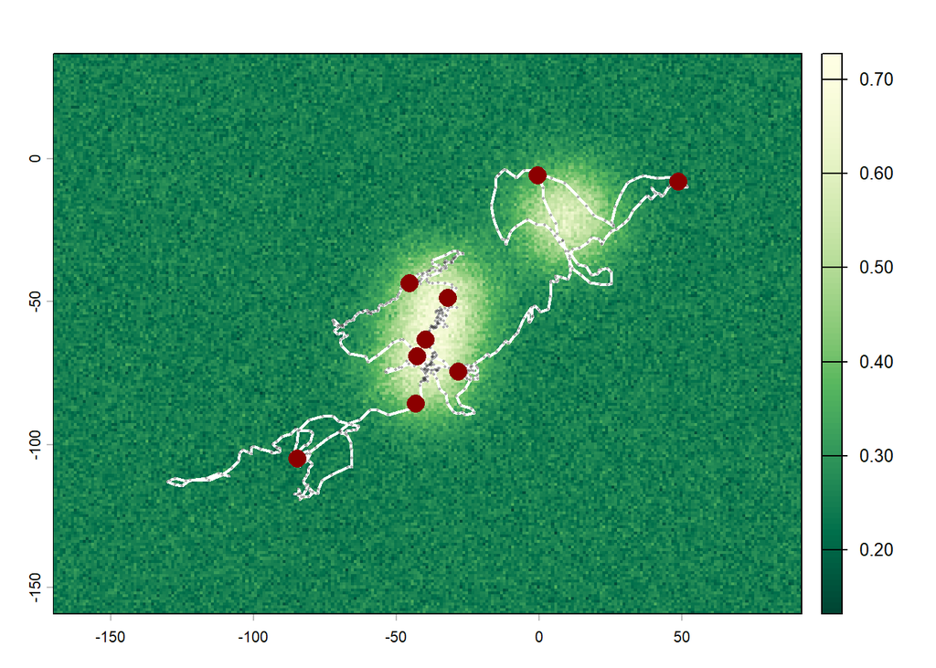

```r
plot(r,
     col = hcl.colors(100, "YlGn"))

lines(df$X, df$Y,
      col = "white",
      lwd = 2)

points(df$X, df$Y,
       pch = 16,
       cex = 0.3,
       col = adjustcolor("grey20", alpha.f = 0.4))

points(df_ind$X, df_ind$Y,
       pch = 16,
       cex = 1.8,
       col = "darkred")
```

Solo tenemos 9 localizaciones útiles de las 609 que teníamos… esto parece ser gravísimo, pero en realidad no debería serlo. Aunque esto remarca la importancia de diseñar bien la recolección de datos (hicimos mucho esfuerzo o gastamos mucha batería al pedo).

Pero también podemos ser más conservadores y establecer un umbral de autocorrelación un poco mayor. Ej. del 0.7.

```r
threshold <- 0.7

acf_dat_no0 <- acf_dat[acf_dat$lag > 0, ] # evitamos que se compare consigo misma.

tau_lag <- acf_dat_no0$lag[which(acf_dat_no0$rho_xy < threshold)[1]]

tau_lag
```

```
## [1] 30
```

```r
tau_time <- tau_lag * dt

tau_time
```

```
## Time difference of 30 hours
```

Bajo a 30 horas.. es decir, que si dos locs están a mas de 30 horas entonces podemos asumirlas independientes.

```r
df_ind_rata <- df[seq(1, nrow(df), by = tau_lag), ]
```

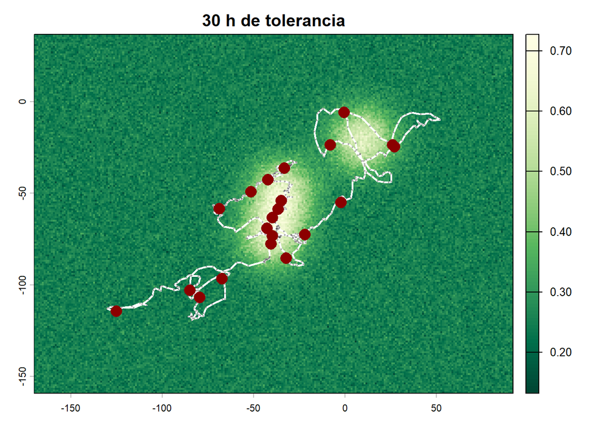

```r
plot(r,
     main = "30 h de tolerancia",
     col = hcl.colors(100, "YlGn"))

lines(df$X, df$Y,
      col = "white",
      lwd = 2)

points(df$X, df$Y,
       pch = 16,
       cex = 0.3,
       col = adjustcolor("grey20", alpha.f = 0.4))

points(df_ind_rata$X, df_ind_rata$Y,
       pch = 16,
       cex = 1.8,
       col = "darkred")
```

## Usados vs disponible

Ya tenemos un conjunto de puntos usados que vamos a tratar como suficientemente independientes. En nuestro objeto `df_ind_rata`, cada fila representa una localización usada por el animal.

Para ajustar una RSF necesitamos comparar esos puntos usados contra puntos disponibles. Los puntos disponibles son una muestra de los lugares que el animal podría haber usado bajo una definición particular de disponibilidad.

En este primer ejemplo vamos a definir la disponibilidad usando el **MCP 100%**, es decir, el polígono mínimo convexo que contiene todos los puntos usados. Luego vamos a generar **10 puntos disponibles por cada punto usado** dentro de ese polígono.

```r
library(sf)
library(terra)

used_sf <- st_as_sf(df_ind_rata,
                    coords = c("X", "Y"),
                    crs = st_crs(crs(r)))
```

Con `st_as_sf()` convertimos la tabla de puntos usados en un objeto espacial. Las columnas `X` e `Y` pasan a definir la geometría de puntos. Usamos el mismo sistema de coordenadas del raster para que todas las capas estén en la misma referencia espacial.

### MCP 100%

Delimitamos dónde debemos generar estos puntos disponibles.. un criterio muy establecido es usar el mcp 100 %, que representaría dónde podría haber llegado el animal.. Definimos un CRS en UTM para trabajar con metros y poder hacer calculos de distancias, areas, lo que sea.

```r
used_sf <- st_as_sf(df_ind_rata,
                    coords = c("X", "Y"),
                    crs = 32721)
```

Antes vimos otros métodos con R base o con otros paquetes, pero para seguir en sf aprovecho y muestro otra forma de calcular el MCP.

```r
mcp_100 <- used_sf |>
  st_union() |>
  st_convex_hull()
```

El MCP 100% se obtiene uniendo todos los puntos usados en una sola geometría y calculando el polígono convexo mínimo que los contiene. Ese polígono representa una definición simple del área disponible.

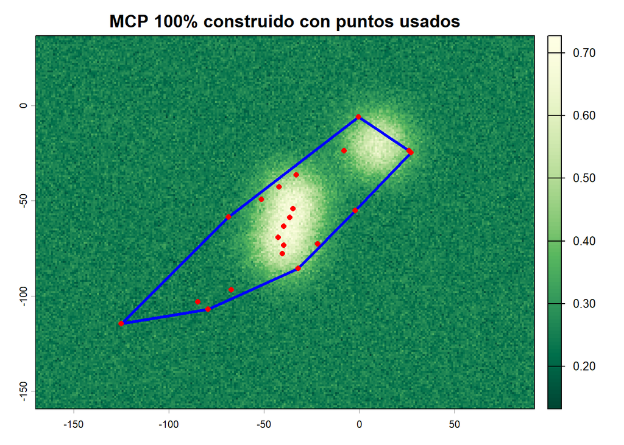

```r
plot(r,
     main = "MCP 100% construido con puntos usados",
     col = hcl.colors(100, "YlGn"))

plot(st_geometry(mcp_100),
     add = TRUE,
     border = "blue",
     lwd = 3)

plot(st_geometry(used_sf),
     add = TRUE,
     pch = 16,
     cex = 0.8,
     col = "red")
```

### Puntos disponibles

Ahora generamos puntos al azar dentro del MCP 100%. En este ejemplo usamos 10 puntos disponibles por cada punto usado. Esta proporción es común en ejemplos introductorios porque describe razonablemente bien la disponibilidad sin hacer el objeto demasiado grande.

Ponemos un seed porque tenemos un proceso aleatorio

```r
set.seed(321)

n_used <- nrow(used_sf)
n_available <- n_used * 10

available_sf <- st_sample(mcp_100,
                          size = n_available,
                          type = "random")

available_sf <- st_sf(
  used = 0,
  geometry = available_sf)
```

La función `st_sample()` genera puntos aleatorios dentro del polígono. En este caso los puntos caen dentro del MCP 100%, por lo tanto representan el ambiente disponible bajo nuestra definición de disponibilidad.

A estos puntos les asignamos `used = 0`. Esto no quiere decir que sean ausencias reales. Sólo indica que son puntos disponibles generados para comparar contra los puntos usados.

```r
used_rsf_sf <- used_sf[, c("geometry")]
used_rsf_sf$used <- 1

used_rsf_sf <- used_rsf_sf[, c("used", "geometry")]
```

A los puntos observados les asignamos `used = 1`. Estos son los sitios donde efectivamente registramos al animal, luego del remuestreo usado para reducir la autocorrelación temporal.

```r
rsf_sf <- rbind(used_rsf_sf, available_sf)

table(rsf_sf$used)
```

```
##
##   0   1
## 210  21
```

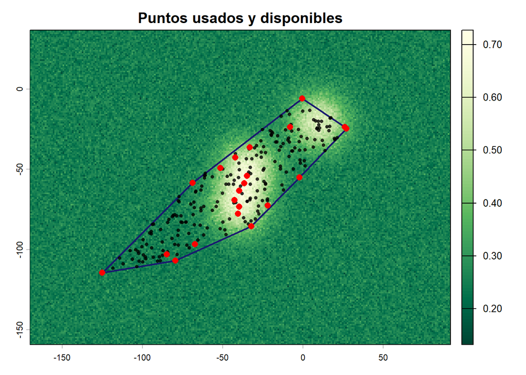

```r
plot(r,
     main = "Puntos usados y disponibles",
     col = hcl.colors(100, "YlGn"))

plot(st_geometry(mcp_100),
     add = TRUE,
     border = "midnightblue",
     lwd = 2)

plot(st_geometry(available_sf),
     add = TRUE,
     pch = 16,
     cex = 0.6,
     col = adjustcolor("black", alpha.f = 0.8))

plot(st_geometry(used_rsf_sf),
     add = TRUE,
     pch = 16,
     cex = 1.1,
     col = "red")
```

## Covariables

Bien, ahora tenemos nuestra data.frame de puntos usados y puntos disponibles `rsf_sf`. Entonces lo que queda antes de ajustar el rsf es extraer la covariable de interes.. NDVI en este caso.

```r
rsf_coords <- st_coordinates(rsf_sf)

rsf_sf$X <- rsf_coords[, 1]
rsf_sf$Y <- rsf_coords[, 2]
```

```r
rsf_ndvi <- terra::extract(r, rsf_sf)
rsf_sf$NDVI <- rsf_ndvi$NDVI
head(rsf_sf)
```

|  | used | geometry | X | Y | NDVI |
| --- | --- | --- | --- | --- | --- |
| 1 | 1 |  | -0.5963595 | -5.769545 | 0.3584165 |
| 2 | 1 |  | -8.0744847 | -23.585662 | 0.4157030 |
| 3 | 1 |  | 26.1507765 | -23.604542 | 0.3811880 |
| 4 | 1 |  | 26.9379439 | -24.535234 | 0.3392132 |
| 5 | 1 |  | -2.1554943 | -54.909486 | 0.2295574 |
| 6 | 1 |  | -22.0650482 | -72.560807 | 0.4129310 |

Bien, tenemos una df bastante sencilla.. Un set de puntos usados independientes entre si y 10 veces más de puntos disponibles dentro de un espacio “alcanzable” por el animal. Además cada puntito tiene su valor de NDVI.

## Ajustamos RSF

Ahora vamos a ajustar una RSF usando una regresión logística. La variable respuesta será `used`, donde `used = 1` representa puntos usados y `used = 0` representa puntos disponibles.

Como generamos 10 puntos disponibles por cada punto usado, la base de datos tiene muchos más puntos disponibles que usados. Eso no significa que el animal haya “evitado” todos esos sitios. Los puntos disponibles son una muestra del ambiente disponible, no ausencias reales.

Por eso vamos a usar pesos. La idea es que el conjunto de puntos usados y el conjunto de puntos disponibles tengan el mismo peso total en el modelo.

Guardamos cuánto tenemos de cada uno

```r
rsf_dat <- st_drop_geometry(rsf_sf)

n_used <- sum(rsf_dat$used == 1)
n_available <- sum(rsf_dat$used == 0)
```

Ahora hacemos algo bastante simple.. le asignamos peso ‘1’ a los puntos usados y le asignamos n_used/n_available a los puntos disponibles

```r
rsf_dat$w <- ifelse(rsf_dat$used == 1,
                    1,
                    n_used / n_available)
```

Ajustmos la regresión logistica.. básicamente un GLM binomial, nada más que tenemos que asignar pesos

```r
m_rsf <- glm(used ~ NDVI,
             data = rsf_dat,
             family = binomial,
             weights = w)

summary(m_rsf)
```

```
##
## Call:
## glm(formula = used ~ NDVI, family = binomial, data = rsf_dat,
##     weights = w)
##
## Coefficients:
##             Estimate Std. Error z value Pr(>|z|)
## (Intercept)  -0.9353     0.9382  -0.997    0.319
## NDVI          2.2827     2.1656   1.054    0.292
##
## (Dispersion parameter for binomial family taken to be 1)
##
##     Null deviance: 58.224  on 230  degrees of freedom
## Residual deviance: 57.081  on 229  degrees of freedom
## AIC: 32.61
##
## Number of Fisher Scoring iterations: 4
```

Aunque el coeficiente de NDVI es positivo, el intervalo de incertidumbre es grande y el efecto no resulta estadísticamente claro. Por lo tanto, en este ejemplo no deberíamos concluir que existe selección fuerte por NDVI. Más bien, el resultado sugiere una tendencia positiva, pero con bastante incertidumbre.

Al aplicar `exp()` a los coeficientes obtenemos los odds ratios. Para `NDVI`, un valor mayor que 1 indica selección positiva: a mayor NDVI, mayor uso relativo. Un valor menor que 1 indica selección negativa.

Sin embargo, hay que tener cuidado: como NDVI va de 0 a 1, un cambio de una unidad completa representa pasar del mínimo al máximo posible de NDVI. Por eso muchas veces conviene escalar NDVI antes de ajustar el modelo.

```r
coef(m_rsf)
```

```
## (Intercept)        NDVI
##  -0.9352537   2.2826936
```

```r
exp(coef(m_rsf))
```

```
## (Intercept)        NDVI
##   0.3924863   9.8030501
```

El intercepto exponenciado no es el foco principal de interpretación en una RSF de uso-disponibilidad. Su valor depende del diseño de muestreo y de la escala de la covariable. En este caso representa el valor esperado de uso relativo cuando `NDVI = 0`, pero no lo vamos a interpretar ecológicamente en detalle.

El modelo sugiere que los sitios con NDVI alto tienen mayor uso relativo que los sitios con NDVI bajo. En este caso, el odds ratio estimado es aproximadamente 9.8, lo que indica una tendencia positiva fuerte en la selección relativa por NDVI.

Otra forma de explicarlo

```r
exp(2.2827 * 0.1)
```

```
## [1] 1.256425
```

Por cada aumento de 0.1 unidades de NDVI, el uso relativo aumenta aproximadamente 1.26 veces, es decir, alrededor de un 26%.

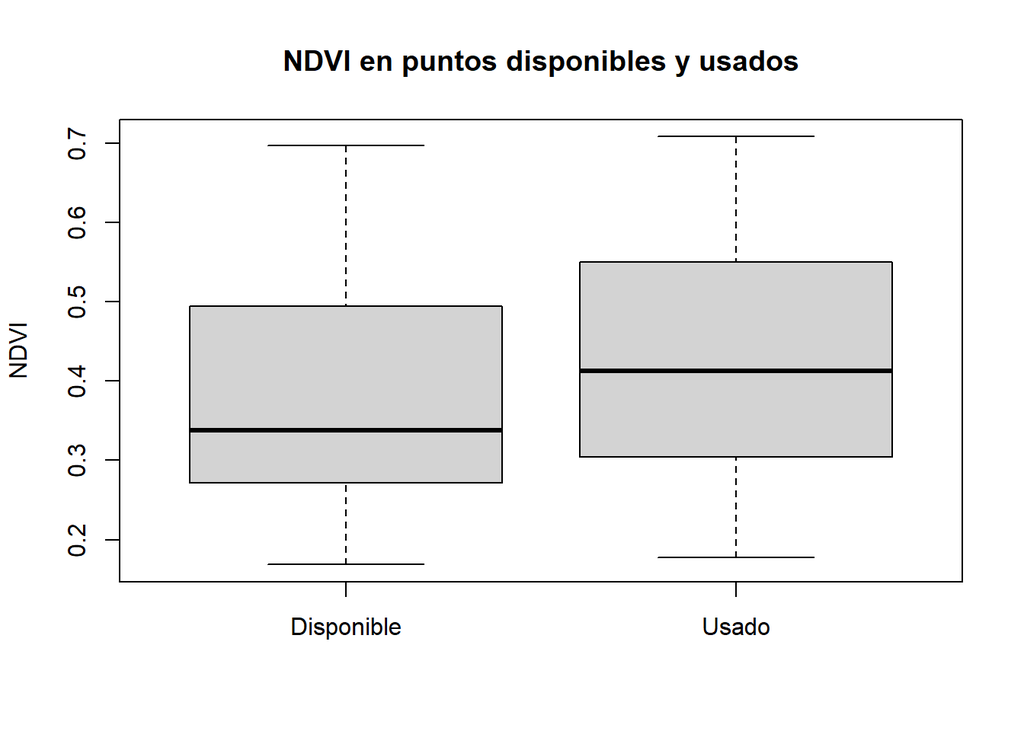

```r
boxplot(NDVI ~ used,
        data = rsf_dat,
        names = c("Disponible", "Usado"),
        ylab = "NDVI",
        xlab = "",
        main = "NDVI en puntos disponibles y usados")
```

**Fuerza de Selección**

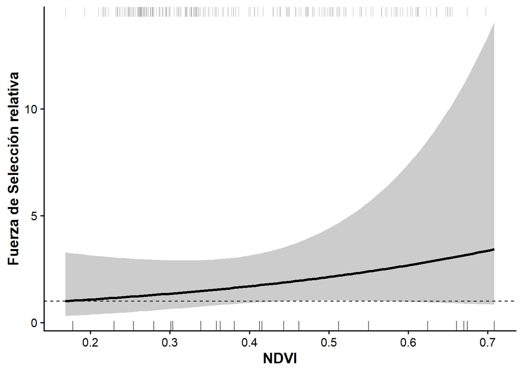

```r
ndvi_seq <- seq(min(rsf_dat$NDVI, na.rm = TRUE),
                max(rsf_dat$NDVI, na.rm = TRUE),
                length.out = 100)

ndvi_mean <- mean(rsf_dat$NDVI, na.rm = TRUE)
ndvi_sd   <- sd(rsf_dat$NDVI, na.rm = TRUE)

pred_dat <- data.frame(
  NDVI = ndvi_seq,
  NDVI_s = (ndvi_seq - ndvi_mean) / ndvi_sd
)

pred_link <- predict(m_rsf,
                     newdata = pred_dat,
                     type = "link",
                     se.fit = TRUE)

pred_dat$fit_link <- pred_link$fit
pred_dat$se_link  <- pred_link$se.fit

pred_dat$rsf <- exp(pred_dat$fit_link)

pred_dat$rsf_lwr <- exp(pred_dat$fit_link - 1.96 * pred_dat$se_link)
pred_dat$rsf_upr <- exp(pred_dat$fit_link + 1.96 * pred_dat$se_link)

library(ggplot2)

min_rsf <- min(pred_dat$rsf, na.rm = TRUE)

pred_dat$rsf_rel <- pred_dat$rsf / min_rsf
pred_dat$rsf_lwr_rel <- pred_dat$rsf_lwr / min_rsf
pred_dat$rsf_upr_rel <- pred_dat$rsf_upr / min_rsf

rsf_dat$tipo <- ifelse(rsf_dat$used == 1,
                       "Usado",
                       "Disponible")

ggplot(pred_dat, aes(x = NDVI, y = rsf_rel)) +

  geom_ribbon(aes(ymin = rsf_lwr_rel,
                  ymax = rsf_upr_rel),
              alpha = 0.25) +

  geom_line(linewidth = 1.2) +

  geom_hline(yintercept = 1,
             linetype = "dashed",
             linewidth = 0.5) +

  geom_rug(data = rsf_dat[rsf_dat$used == 1, ],
           aes(x = NDVI),
           inherit.aes = FALSE,
           sides = "b",
           alpha = 0.6,
           linewidth = 0.4) +

  geom_rug(data = rsf_dat[rsf_dat$used == 0, ],
           aes(x = NDVI),
           inherit.aes = FALSE,
           sides = "t",
           alpha = 0.25,
           linewidth = 0.3) +

  labs(x = "NDVI",
       y = "Fuerza de Selección relativa") +

  theme_classic(base_size = 14) +

  theme(
    plot.title = element_text(face = "bold"),
    plot.subtitle = element_text(size = 11),
    axis.title = element_text(face = "bold"))
```

## Análisis de sensibilidad

En los RSF tenemos distintas formas de generar los puntos disponibles, la más común es la que hicimos ahora “random”. Pero también existen otras variantes, como “regular” o haciedno LoCoH. Particularmente en la generación aleatoria de puntos disponibles necesitamos hacer un ánalsiis de sensibilidad. Es decir, de alguna forma asegurarnos que nuestro modelo es robusto y que no depende del azar.

Hasta ahora usamos 10 puntos disponibles por cada punto usado. Esa decisión es razonable para un ejemplo inicial, pero no deja de ser una decisión arbitraria. En un RSF, los puntos disponibles son una muestra del ambiente disponible. Por lo tanto, si usamos muy pocos puntos disponibles, podríamos describir mal la disponibilidad ambiental.

Usando un script que proponen Fieberg et al. (2021) en su Apendice A,  
Una forma simple de evaluar esto es repetir el análisis varias veces usando distintas cantidades de puntos disponibles. Por ejemplo, podemos generar 1, 5, 10, 50 y 100 puntos disponibles por cada punto usado. Si el coeficiente de NDVI cambia mucho entre repeticiones o entre tamaños de muestra, quiere decir que el modelo es sensible a cómo muestreamos la disponibilidad. Si el coeficiente se estabiliza, tenemos más confianza en que la cantidad de puntos disponibles es suficiente para describir el ambiente disponible.

```r
library(sf)
library(terra)
library(dplyr)
library(purrr)
library(tidyr)
library(broom)
library(ggplot2)
```

Creamos la función… con todos los pasos. Esta función no es exactamente la que usan en el estudio de Fieberg et al. (2021) pero operativamente es lo mismo. En este caso, estamos usando una muy especifica para nuestro caso, pero es modificable a otros casos.

```r
fit_rsf_available <- function(n_available, used_sf, mcp_100, r){

  available_geom <- st_sample(mcp_100,
                              size = n_available,
                              type = "random")

  available_sf <- st_sf(
    used = 0,
    geometry = available_geom
  )

  used_rsf_sf <- used_sf[, "geometry"]
  used_rsf_sf$used <- 1
  used_rsf_sf <- used_rsf_sf[, c("used", "geometry")]

  rsf_sf <- rbind(used_rsf_sf, available_sf)

  rsf_vect <- terra::vect(rsf_sf)
  ndvi_vals <- terra::extract(r, rsf_vect)

  rsf_sf$NDVI <- ndvi_vals$NDVI

  rsf_dat_tmp <- st_drop_geometry(rsf_sf)
  rsf_dat_tmp <- rsf_dat_tmp |>
    filter(!is.na(NDVI))

  n_used_tmp <- sum(rsf_dat_tmp$used == 1)
  n_avail_tmp <- sum(rsf_dat_tmp$used == 0)

  rsf_dat_tmp$w <- ifelse(rsf_dat_tmp$used == 1,
                          1,
                          n_used_tmp / n_avail_tmp)

  m <- glm(used ~ NDVI,
           data = rsf_dat_tmp,
           family = binomial,
           weights = w)

  broom::tidy(m)}
```

```r
n_frac <- c(1, 5, 10, 50, 100)

n_used <- nrow(used_sf)

n_pts <- ceiling(n_used * n_frac)

n_rep <- 20
```

Ejecutamos la función.. puede demorar bastante, pero ahora tenemos re pocos puntos

```r
set.seed(777)

sens_grid <- tidyr::expand_grid(
  frac = n_frac,
  rep = 1:n_rep) |>
  mutate(
    n_available = ceiling(n_used * frac))

sens_res <- sens_grid |>
  mutate(
    res = purrr::map(n_available,
                     ~ fit_rsf_available(n_available = .x,
                                         used_sf = used_sf,
                                         mcp_100 = mcp_100,
                                         r = r))) |>
  tidyr::unnest(res)

head(sens_res)
```

| frac | rep | n_available | term | estimate | std.error | statistic | p.value |
| --- | --- | --- | --- | --- | --- | --- | --- |
| 1 | 1 | 21 | (Intercept) | -1.4545386 | 0.9334253 | -1.5582807 | 0.11916673 |
| 1 | 1 | 21 | NDVI | 3.6901359 | 2.2419584 | 1.6459431 | 0.09977548 |
| 1 | 2 | 21 | (Intercept) | -0.8031641 | 0.9241293 | -0.8691036 | 0.38479049 |
| 1 | 2 | 21 | NDVI | 1.9468657 | 2.1141250 | 0.9208849 | 0.35711054 |
| 1 | 3 | 21 | (Intercept) | -0.8712168 | 0.9292491 | -0.9375493 | 0.34847610 |
| 1 | 3 | 21 | NDVI | 2.1198272 | 2.1353340 | 0.9927380 | 0.32083764 |

```r
sens_ndvi <- sens_res |>
  filter(term == "NDVI")
```

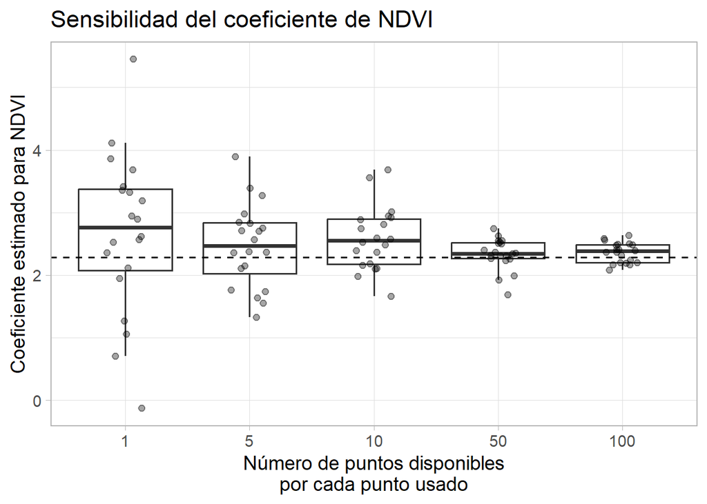

```r
ggplot(sens_ndvi,
       aes(x = factor(frac),
           y = estimate)) +
  geom_boxplot(outlier.shape = NA) +
  geom_jitter(width = 0.15,
              alpha = 0.35,
              size = 1.8) +
  geom_hline(yintercept = coef(m_rsf)["NDVI"],
             linetype = "dashed",
             linewidth = 0.7) +
  labs(x = "Número de puntos disponibles\npor cada punto usado",
       y = "Coeficiente estimado para NDVI",
       title = "Sensibilidad del coeficiente de NDVI") +
  theme_light(base_size = 14)
```

```r
sens_summary <- sens_ndvi |>
  group_by(frac) |>
  summarise(
    mean_beta = mean(estimate, na.rm = TRUE),
    median_beta = median(estimate, na.rm = TRUE),
    sd_beta = sd(estimate, na.rm = TRUE),
    iqr_beta = IQR(estimate, na.rm = TRUE),
    .groups = "drop"
  )
```

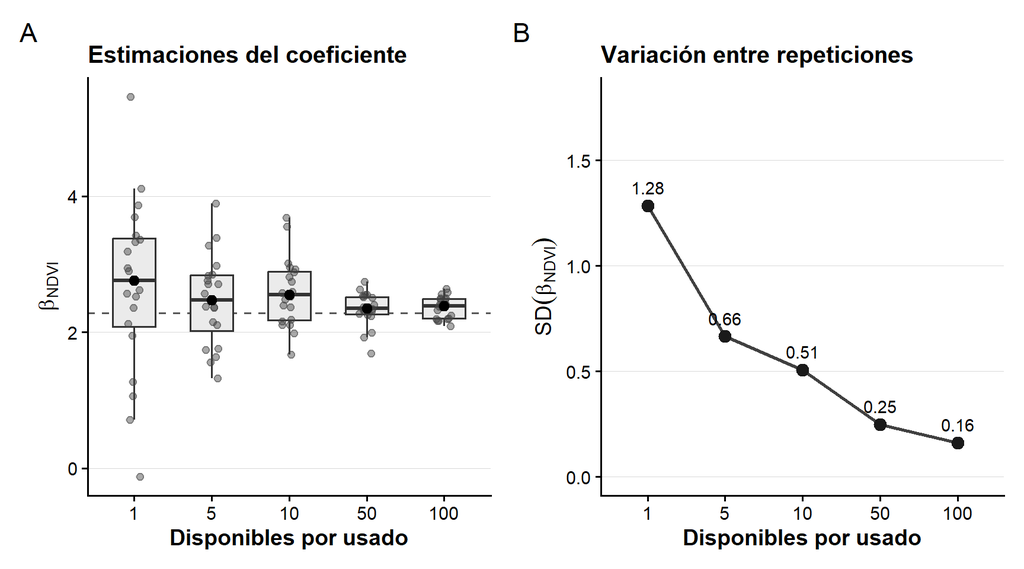

```r
library(patchwork)

sens_ndvi <- sens_ndvi |>
  mutate(frac_f = factor(frac, levels = c(1, 5, 10, 50, 100)))

sens_summary <- sens_summary |>
  mutate(frac_f = factor(frac, levels = c(1, 5, 10, 50, 100)))

beta_ref <- coef(m_rsf)["NDVI"]

theme_rsf <- theme_classic(base_size = 14) +
  theme(
    plot.title = element_text(face = "bold", size = 15),
    plot.subtitle = element_text(size = 11),
    axis.title = element_text(face = "bold"),
    axis.text = element_text(color = "black"),
    strip.background = element_blank(),
    strip.text = element_text(face = "bold"),
    panel.grid.major.y = element_line(linewidth = 0.25, color = "grey85"),
    legend.position = "none")

p_coef <- ggplot(sens_ndvi,
                 aes(x = frac_f,
                     y = estimate)) +

  geom_hline(yintercept = beta_ref,
             linetype = "dashed",
             linewidth = 0.7,
             color = "grey35") +

  geom_boxplot(width = 0.55,
               outlier.shape = NA,
               fill = "grey92",
               color = "grey20",
               linewidth = 0.6) +

  geom_jitter(width = 0.10,
              height = 0,
              alpha = 0.45,
              size = 1.8,
              color = "grey25") +

  stat_summary(fun = median,
               geom = "point",
               size = 2.6,
               color = "black") +

  labs(x = "Disponibles por usado",
       y = expression(beta[NDVI]),
       title = "Estimaciones del coeficiente") +

  theme_rsf

p_var <- ggplot(sens_summary,
                aes(x = frac_f,
                    y = sd_beta,
                    group = 1)) +

  geom_line(linewidth = 1,
            color = "grey25") +

  geom_point(size = 3.2,
             color = "grey10") +

  geom_text(aes(label = round(sd_beta, 2)),
            vjust = -0.9,
            size = 3.8) +
  scale_y_continuous(limits = c(0,1.8)) +

  labs(x = "Disponibles por usado",
       y = expression(SD(beta[NDVI])),
       title = "Variación entre repeticiones") +

  expand_limits(y = 0) +

  theme_rsf

p_coef + p_var +
  plot_annotation(
    tag_levels = "A",
    theme = theme(
      plot.title = element_text(size = 17),
      plot.tag = element_text(size = 15)))
```

este plot resume muy bien qué pasaría si cambiamos el n de puntos disponibles por locations.. si solo hiciesemos 1 punto por cada posicion tend´riamos mucho riesgo (por azar) de tener conclusiones super diferentes.. desde un beta mayor a 5 hasta uno menor a 0, con 5 la cosa mejora, pero la estabilidad clara ocurre cuando tenemos entre 50 y 100 puntos disponibles.. De todos modos mientras más puntos disponibles más carga computacional..

## Extrapolación al paisaje

Una vez ajustado el RSF, podemos usar el modelo para predecir valores de uso relativo en todo el paisaje. Es decir, podemos aplicar el modelo a cada celda del raster ambiental y construir un mapa donde los valores altos indiquen sitios relativamente más seleccionados.

Sin embargo, hay que tener cuidado con el lenguaje. En un RSF de uso-disponibilidad, la predicción del modelo no debe interpretarse directamente como una probabilidad absoluta de presencia. Es mejor interpretarla como una superficie de **uso relativo**, **selección relativa** o **probabilidad relativa de uso**.

En otras palabras, el mapa nos dice qué lugares tienen mayor valor relativo según las covariables ambientales del modelo, no la probabilidad real de que el animal esté allí en un momento determinado.

```r
m_rsf <- glm(used ~ NDVI,
             data = rsf_dat,
             family = binomial,
             weights = w)
```

#### Predicción en escala logística

```r
rsf_prob <- terra::predict(r,
                           m_rsf,
                           type = "response")

names(rsf_prob) <- "probabilidad_relativa_uso"
```

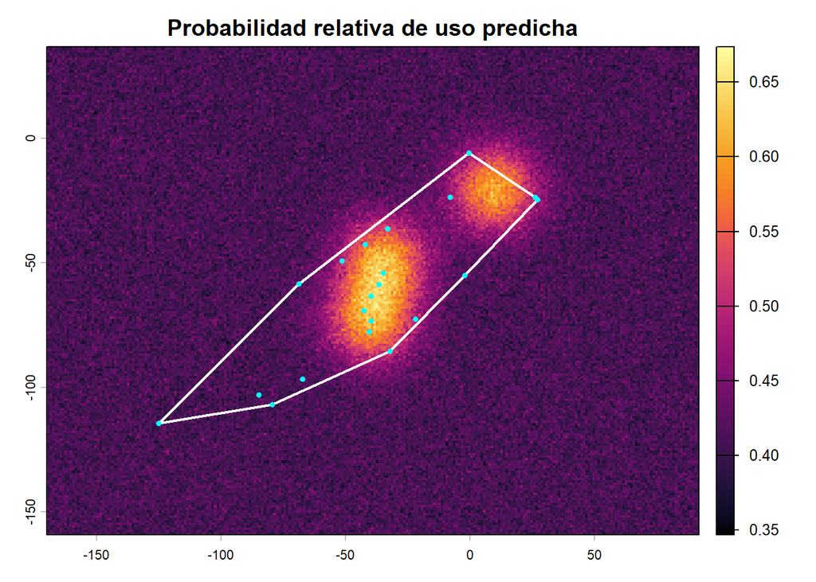

```r
plot(rsf_prob,
     main = "Probabilidad relativa de uso predicha",
     col = hcl.colors(100, "Inferno"))

plot(st_geometry(mcp_100),
     add = TRUE,
     border = "white",
     lwd = 2)

plot(st_geometry(used_sf),
     add = TRUE,
     pch = 16,
     cex = 0.6,
     col = "cyan")
```

Este mapa muestra la predicción del RSF sobre el paisaje. Las celdas con valores más altos corresponden a sitios con mayor uso relativo esperado según su valor de NDVI. Como el coeficiente de NDVI fue positivo, las zonas con NDVI más alto reciben valores predichos más altos.

Aunque la escala del mapa va de 0 a 1, no debemos interpretarla como una probabilidad absoluta de encontrar al animal. La interpretamos como una probabilidad relativa de uso condicionada al modelo y a la definición de disponibilidad.

```r
rsf_link <- terra::predict(r,
                           m_rsf,
                           type = "link")

rsf_score <- exp(rsf_link)

names(rsf_score) <- "RSF_score"
```

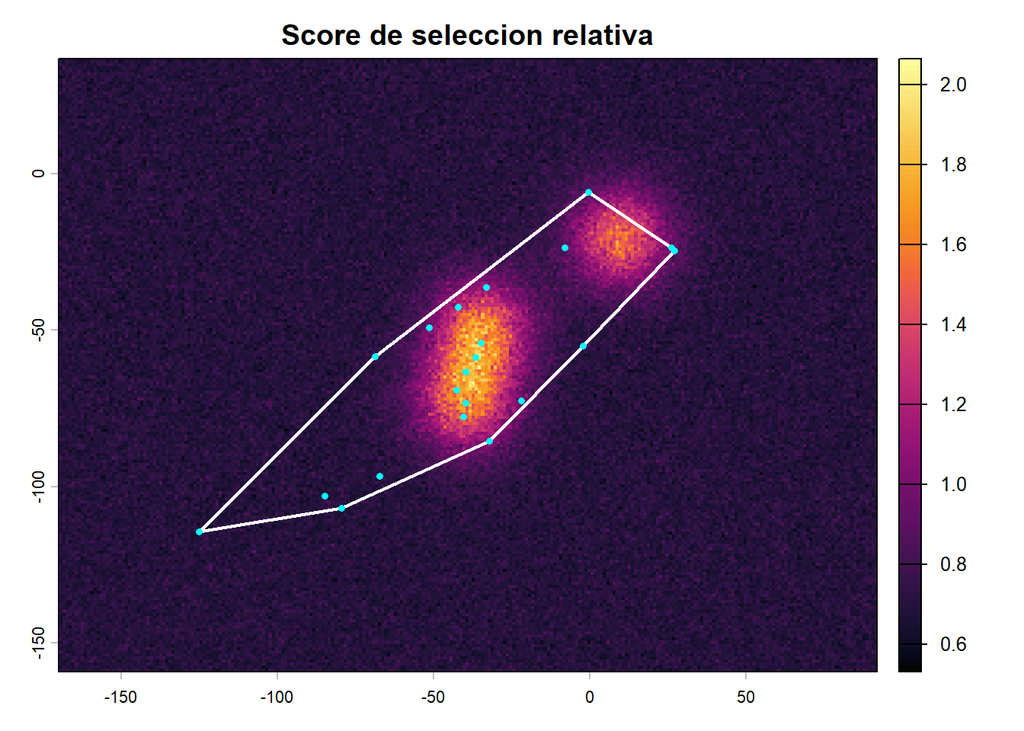

```r
plot(rsf_score,
     main = "Score de seleccion relativa",
     col = hcl.colors(100, "Inferno"))

plot(st_geometry(mcp_100),
     add = TRUE,
     border = "white",
     lwd = 2)

plot(st_geometry(used_sf),
     add = TRUE,
     pch = 16,
     cex = 0.6,
     col = "cyan")
```

# Flujo de trabajo

```
Trayectoria GPS
      ↓
Evaluar autocorrelación
      ↓
Seleccionar puntos usados
      ↓
Definir covariables ambientales
      ↓
Definir disponibilidad (MCP 100%)
      ↓
Generar puntos disponibles
      ↓
Extraer covariables
      ↓
Análisis de sensibilidad
      ↓
Ajustar RSF
      ↓
Interpretar
      ↓
Predecir selección relativa
      ↓
Extrapolar
```

# Movebank

vamos con un estudio de Perros Mapache (*Nyctereutes procyonides*) en Finlandia.

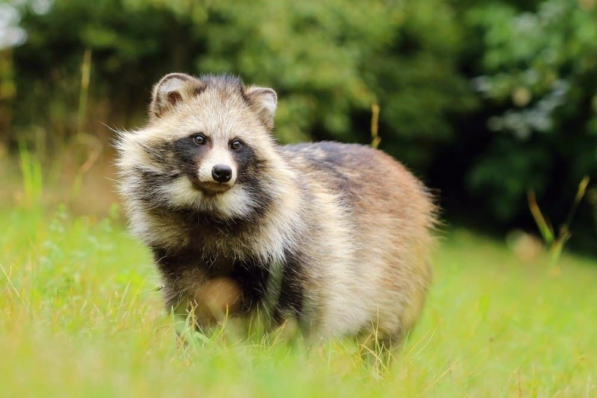

```r
library(sf)
library(dplyr)
library(ggplot2)
```

```r
rac <- read.csv("data/tables/rac_dogs.csv")
```

```r
summary(rac)
```

```
##     event.id           visible           timestamp         location.long
##  Min.   :3.952e+10   Length:18392       Length:18392       Min.   :21.06
##  1st Qu.:3.952e+10   Class :character   Class :character   1st Qu.:22.14
##  Median :3.952e+10   Mode  :character   Mode  :character   Median :22.36
##  Mean   :3.952e+10                                         Mean   :22.12
##  3rd Qu.:3.952e+10                                         3rd Qu.:22.45
##  Max.   :3.952e+10                                         Max.   :22.85
##
##   location.lat      gps.hdop      sensor.type
##  Min.   :59.84   Min.   : 0.000   Length:18392
##  1st Qu.:59.95   1st Qu.: 0.900   Class :character
##  Median :60.04   Median : 1.200   Mode  :character
##  Mean   :60.07   Mean   : 1.571
##  3rd Qu.:60.13   3rd Qu.: 1.800
##  Max.   :60.53   Max.   :25.500
##                  NA's   :8
##  individual.taxon.canonical.name tag.local.identifier
##  Length:18392                    Length:18392
##  Class :character                Class :character
##  Mode  :character                Mode  :character
##
##
##
##
##  individual.local.identifier  study.name
##  Length:18392                Length:18392
##  Class :character            Class :character
##  Mode  :character            Mode  :character
##
##
##
##
```

```r
length(unique(rac$individual.local.identifier))
```

```
## [1] 30
```

30 perros mapache, mucho.

```r
rac_sf <- rac |>
  filter(
    !is.na(location.long),
    !is.na(location.lat)
  ) |>
  st_as_sf(
    coords = c("location.long", "location.lat"),
    crs = 4326  )
```

### Shape Costas

Descargamos el shape de Finlandia.. `library(rnaturalearth)` es otra muy buena opción

```r
library(giscoR)
finlandia <- gisco_get_countries(
  country = "Finland",
  resolution = "01",
  epsg = 4326)
```

Finalndia tiene latitudes demasiado altas, podemos usar UTM pero puede haber distorsión. Mejor usamos un Sistema métrico de Finlandia

```r
finlandia_3067 <- st_transform(finlandia, 3067)
rac_3067 <- st_transform(rac_sf, 3067)

bb <- st_bbox(rac_3067)

xpad <- diff(bb[c("xmin", "xmax")]) * 0.1
ypad <- diff(bb[c("ymin", "ymax")]) * 0.1

library(viridis)

ggplot() +
  geom_sf(data = finlandia_3067, fill = "grey95", color = "grey20") +
  geom_sf(
    data = rac_3067,
    aes(color = individual.local.identifier),
    size = 0.9,
    alpha = 0.65
  ) +
  coord_sf(
    xlim = c(as.numeric(bb["xmin"] - xpad), as.numeric(bb["xmax"] + xpad)),
    ylim = c(as.numeric(bb["ymin"] - ypad), as.numeric(bb["ymax"] + ypad)),
    crs = st_crs(rac_3067)
  ) +
  scale_color_viridis_d(
    option = "turbo",
    end = 0.9,
    name = "Individuo"
  ) +
  theme_minimal(base_size = 12) +
  theme(
    legend.position = "right",
    panel.grid.minor = element_blank()
  )
```

[figure not shown]

Algo que puede ser interesante es la distancia al mar, para ver si usan mucho las costas, que se yo

Antes recortamos el Shape de Finlandia haciendo un zoom en los perros estos

```r
bb <- st_bbox(rac_3067)

xmin <- as.numeric(bb["xmin"])
xmax <- as.numeric(bb["xmax"])
ymin <- as.numeric(bb["ymin"])
ymax <- as.numeric(bb["ymax"])

xpad <- (xmax - xmin) * 0.1
ypad <- (ymax - ymin) * 0.1

bb_zoom <- st_bbox(
  c(
    xmin = xmin - xpad,
    xmax = xmax + xpad,
    ymin = ymin - ypad,
    ymax = ymax + ypad),
  crs = st_crs(rac_3067))

bb_zoom_sf <- st_as_sfc(bb_zoom)
```

Aca vamos a calcular distancia a las costas pero para todo Finlandia, si lo hiciesemos para el shape recortado va a calcular distnacia al corte (tratandolo como una costa).

```r
costa_finlandia <- finlandia_3067 |>
  st_union() |>
  st_boundary()
```

### Covariable

Lo mantengamos sencillo, vamos con una sola covariable: Distancia a la costa (en m, y por las en km)

```r
rac_3067 <- rac_3067 |>
  mutate(
    dist_costa_m = as.numeric(st_distance(geometry, costa_finlandia)),
    dist_costa_km = dist_costa_m / 1000)
```

Recortamos al tamaño del dataset

```r
costa_crop <- st_crop(costa_finlandia, bb_zoom)
finlandia_crop <- st_crop(finlandia_3067, bb_zoom)
```

```r
library(viridis)
library(terra)
```

```r
res_m <- 500

r_base <- rast(
  ext(
    as.numeric(bb_zoom["xmin"]),
    as.numeric(bb_zoom["xmax"]),
    as.numeric(bb_zoom["ymin"]),
    as.numeric(bb_zoom["ymax"])),
  resolution = res_m,
  crs = st_crs(finlandia_3067)$wkt)

costa_vect <- vect(costa_finlandia)

costa_r <- rasterize(
  costa_vect,
  r_base,
  field = 1)

dist_costa <- distance(costa_r)
dist_costa_km <- dist_costa / 1000

fin_crop_vect <- vect(finlandia_crop)

dist_costa_crop <- dist_costa_km |>
  crop(fin_crop_vect) |>
  mask(fin_crop_vect)

dist_df <- as.data.frame(dist_costa_crop, xy = TRUE, na.rm = TRUE)

names(dist_df)[3] <- "dist_costa_km"
```

### Plot Covariable

```r
ggplot() +
  geom_raster(
    data = dist_df,
    aes(x = x, y = y, fill = dist_costa_km)) +
  geom_sf(
    data = finlandia_crop,
    fill = NA,
    color = "grey15",
    linewidth = 0.35) +
  scale_fill_viridis_c(
    option = "mako",
    direction = -1,
    name = "Distancia a\nla costa (km)") +
  coord_sf(
    xlim = c(bb_zoom["xmin"], bb_zoom["xmax"]),
    ylim = c(bb_zoom["ymin"], bb_zoom["ymax"]),
    crs = st_crs(finlandia_3067),
    expand = FALSE) +
  theme_void(base_size = 12) +
  theme(
    legend.position = "right",
    legend.title = element_text(size = 10),
    legend.text = element_text(size = 9),
    plot.background = element_rect(fill = "white", color = NA),
    panel.background = element_rect(fill = "white", color = NA))
```

[figure not shown]

```r
ggplot() +
  geom_sf(data = finlandia_crop, fill = "grey95", color = "grey60") +
  geom_sf(data = costa_crop, color = "black", linewidth = 0.5) +
  geom_sf(
    data = rac_3067,
    aes(color = dist_costa_km),
    size = 0.7,
    alpha = 0.7
  ) +
  coord_sf(
    xlim = c(bb_zoom["xmin"], bb_zoom["xmax"]),
    ylim = c(bb_zoom["ymin"], bb_zoom["ymax"]),
    crs = st_crs(rac_3067)
  ) +
  theme_minimal() +
  labs(
    color = "Distancia\na costa (km)" )
```

[figure not shown]

Veamos un solo perro

```r
rac_3067 <- rac_3067 |>
  mutate(
    dist_costa_m = as.numeric(st_distance(geometry, costa_finlandia)))

id_sel <- "R11"

rac_id <- rac_3067 |>
  filter(individual.local.identifier == id_sel)
```

zoom a R11

```r
bb_id <- st_bbox(rac_id)

xmin <- as.numeric(bb_id["xmin"])
xmax <- as.numeric(bb_id["xmax"])
ymin <- as.numeric(bb_id["ymin"])
ymax <- as.numeric(bb_id["ymax"])

xpad <- (xmax - xmin) * 0.5
ypad <- (ymax - ymin) * 0.3

bb_id_zoom <- st_bbox(
  c(
    xmin = xmin - xpad,
    xmax = xmax + xpad,
    ymin = ymin - ypad,
    ymax = ymax + ypad
  ),
  crs = st_crs(rac_id)
)
```

Recortamos un poco más

```r
finlandia_id_crop <- st_crop(finlandia_3067, bb_id_zoom)
costa_id_crop <- st_crop(costa_finlandia, bb_id_zoom)
```

```r
ggplot() +
  geom_sf(data = finlandia_id_crop, fill = "grey97", color = "grey75") +
  geom_sf(data = costa_id_crop, color = "grey15", linewidth = 0.45) +
  geom_sf(
    data = rac_id,
    aes(fill = dist_costa_m),
    size = 2.6,
    shape = 21,
    color = "black",
    alpha = 0.8
  ) +
  coord_sf(
    xlim = c(as.numeric(bb_id_zoom["xmin"]), as.numeric(bb_id_zoom["xmax"])),
    ylim = c(as.numeric(bb_id_zoom["ymin"]), as.numeric(bb_id_zoom["ymax"])),
    crs = st_crs(rac_3067),
    expand = FALSE
  ) +
  scale_fill_viridis_c(
    option = "magma",
    direction = -1,
    name = "Distancia\na costa (m)"
  ) +
  labs(
    title = paste("Distancia a la costa — individuo", id_sel),
    x = "Este (m)",
    y = "Norte (m)"
  ) +
  theme_minimal(base_size = 12) +
  theme(
    plot.title = element_text(face = "bold"),
    panel.grid.minor = element_blank(),
    legend.position = "right"
  )
```

[figure not shown]

Bien parece que varía bastante

`st_make_valid` es medio de control, sirve para asegurarse que la capa multipoligono no tenga solapamiento entre los poligonos individuales, si es así los corrige (básciamente elimina las partes encimadas)

```r
finlandia_3067 <- st_make_valid(finlandia_3067)

rac_3067 <- rac_3067[
  lengths(st_intersects(rac_3067, finlandia_3067)) >= 0,
]
```

### Formateamos

VAmos hacer lo mismo que siempre, dejar nombres comodos y formatos adecuados- rac_3067 esta bien pero es medio bardo

```r
coords <- st_coordinates(rac_3067)
x <- coords [,1]
y <- coords [,2]

rac_3067$x <- x
rac_3067$y <- y

rac_3067 <- rac_3067 |>
  rename(id = individual.local.identifier) |>
  mutate (t = as.POSIXct(timestamp, format = "%Y-%m-%d %H:%M:%S")) |>
  select(-timestamp)

pepe <- rac_3067 |>
  filter(id == id_sel)

rac_id
```

|  | event.id | visible | timestamp | gps.hdop | sensor.type | individual.taxon.canonical.name | tag.local.identifier | individual.local.identifier | study.name | geometry | dist_costa_m | dist_costa_km |
| --- | --- | --- | --- | --- | --- | --- | --- | --- | --- | --- | --- | --- |
| 1 | 39517654091 | true | 2022-01-18 21:00:00.000 | 6.7 | gps | Nyctereutes procyonoides | R11 | R11 | GPS tracking of raccoon dogs in southern Finland |  | 986.024067 | 0.986024067 |
| 2 | 39517654092 | true | 2022-01-18 23:00:00.000 | 1.1 | gps | Nyctereutes procyonoides | R11 | R11 | GPS tracking of raccoon dogs in southern Finland |  | 911.342325 | 0.911342325 |
| 3 | 39517654093 | true | 2022-01-19 17:00:00.000 | 1.2 | gps | Nyctereutes procyonoides | R11 | R11 | GPS tracking of raccoon dogs in southern Finland |  | 1128.221008 | 1.128221008 |
| 4 | 39517654094 | true | 2022-01-19 21:00:00.000 | 2.0 | gps | Nyctereutes procyonoides | R11 | R11 | GPS tracking of raccoon dogs in southern Finland |  | 1568.666000 | 1.568666000 |
| 5 | 39517654095 | true | 2022-01-19 23:00:00.000 | 0.8 | gps | Nyctereutes procyonoides | R11 | R11 | GPS tracking of raccoon dogs in southern Finland |  | 1090.951804 | 1.090951804 |
| 6 | 39517654096 | true | 2022-01-21 17:00:00.000 | 0.8 | gps | Nyctereutes procyonoides | R11 | R11 | GPS tracking of raccoon dogs in southern Finland |  | 893.532647 | 0.893532647 |
| 7 | 39517654097 | true | 2022-01-21 23:00:00.000 | 0.8 | gps | Nyctereutes procyonoides | R11 | R11 | GPS tracking of raccoon dogs in southern Finland |  | 2696.429537 | 2.696429537 |
| 8 | 39517654098 | true | 2022-01-22 15:00:00.000 | 0.8 | gps | Nyctereutes procyonoides | R11 | R11 | GPS tracking of raccoon dogs in southern Finland |  | 2184.939447 | 2.184939447 |
| 9 | 39517654099 | true | 2022-01-23 17:00:00.000 | 2.2 | gps | Nyctereutes procyonoides | R11 | R11 | GPS tracking of raccoon dogs in southern Finland |  | 2636.267092 | 2.636267092 |
| 10 | 39517654100 | true | 2022-01-23 21:00:00.000 | 3.3 | gps | Nyctereutes procyonoides | R11 | R11 | GPS tracking of raccoon dogs in southern Finland |  | 1528.634537 | 1.528634537 |

[output cut: 578 more lines]

### Independencia

Bien, tenemos a pepe con formato adecuado, vamos a ver la independencia de las localizaciones.

```r
dt <- median(diff(pepe$t))

dt
```

```
## Time difference of 240 mins
```

```r
acf_x <- acf(pepe$x,
             lag.max = 200,
             plot = FALSE)

acf_y <- acf(pepe$y,
             lag.max = 200,
             plot = FALSE)

lags <- as.numeric(acf_x$lag)

rho_x <- as.numeric(acf_x$acf)
rho_y <- as.numeric(acf_y$acf)

rho_xy <- (rho_x + rho_y) / 2

acf_dat <- data.frame(
  lag = lags,
  rho_x = rho_x,
  rho_y = rho_y,
  rho_xy = rho_xy)


threshold <- 1 / exp(1)

acf_dat_no0 <- acf_dat[acf_dat$lag > 0, ]

tau_lag <- acf_dat_no0$lag[which(acf_dat_no0$rho_xy < threshold)[1]]

tau_lag * dt
```

```
## Time difference of 960 mins
```

Tomando un criterio muy conservador vemos que el lag necesario para tener independencia es de 960 mins (16 horas), asumiendo el umbral de 0.37. Vamos con uno más tranca.

```r
threshold <- 0.7

acf_dat_no0 <- acf_dat[acf_dat$lag > 0, ]

tau_lag <- acf_dat_no0$lag[which(acf_dat_no0$rho_xy < threshold)[1]]

tau_lag * dt
```

```
## Time difference of 480 mins
```

Suena razonable, son unas 8 horas. Vamos con ese.

```r
tau_time <- tau_lag * dt

pepe_res <- pepe[order(pepe$t), ]

keep <- logical(nrow(pepe_res))
keep[1] <- TRUE

last_t <- pepe_res$t[1]

for (i in 2:nrow(pepe_res)) {
  if (pepe_res$t[i] - last_t >= tau_time) {
    keep[i] <- TRUE
    last_t <- pepe_res$t[i] }}

pepe_res <- pepe_res[keep, ]
```

Bajamos de 588 locs a 293, de todos modos sigue estando muy bien. tenemos casi trescientes observaciones independientes (o suficientemnete independientes) par aunos de los perros estos

### MCP 100%

Primero el MCP, esto de paso nos ayuda a que no caigan puntos en el agua.. sino tendríamos que hacer una cosa rara

```r
mcp_100 <- pepe_res |>
  st_union() |>
  st_convex_hull()

mcp_100_sf <- st_sf(
  id = unique(pepe_res$id)[1],
  geometry = mcp_100)
```

### Disponibles

Podemos hacer el análisis de sensibilidad, pero toma su tiempito, así que por el momento lo vamos a evitar. Pero debería hacerse

```r
set.seed(321)

n_avail_per_used <- 10
n_avail <- nrow(pepe_res) * n_avail_per_used

avail_geom <- st_sample(
  mcp_100,
  size = n_avail,
  type = "random")

avail_pts <- st_sf(
  id = unique(pepe_res$id)[1],
  used = FALSE,
  geometry = avail_geom)

st_crs(avail_pts) <- st_crs(pepe_res)
```

```r
used_pts <- pepe_res |>
  mutate(used = TRUE)
```

Calculamos distancias para los puntos disponibles

```r
avail_pts <- avail_pts |>
  mutate(
    dist_costa_m = as.numeric(st_distance(geometry, costa_finlandia)))
```

Al pedo, pero nos aseguramos que los usados también tengan esa columna

```r
used_pts <- used_pts |>
  mutate(
    dist_costa_m = as.numeric(st_distance(geometry, costa_finlandia))
  )
```

Unimos los puntos disponibles con los usados

```r
used_rsf <- used_pts |>
  select(id, used, dist_costa_m, geometry)

avail_rsf <- avail_pts |>
  select(id, used, dist_costa_m, geometry)

rsf_pepe <- bind_rows(used_rsf, avail_rsf)
```

```r
table(rsf_pepe$used)
```

```
##
## FALSE  TRUE
##  2930   293
```

```r
rsf_used <- rsf_pepe |>
  filter(used == TRUE)

rsf_avail <- rsf_pepe |>
  filter(used == FALSE)

ggplot() +
  geom_sf(data = finlandia_crop, fill = "grey97", color = "grey80") +
  geom_sf(data = costa_crop, color = "grey20", linewidth = 0.4) +
  geom_sf(data = mcp_100_sf, fill = NA, color = "black", linewidth = 0.7) +

  geom_sf(
    data = rsf_avail,
    aes(color = used),
    size = 0.8,
    alpha = 0.6) +

  geom_sf(
    data = rsf_used,
    aes(color = used),
    size = 1.4,
    alpha = 0.85) +

  scale_color_manual(
    values = c("TRUE" = "red3", "FALSE" = "gold3"),
    labels = c("Disponible", "Usado"),
    name = NULL) +
  coord_sf(
    xlim = c(as.numeric(bb_id_zoom["xmin"]), as.numeric(bb_id_zoom["xmax"])),
    ylim = c(as.numeric(bb_id_zoom["ymin"]), as.numeric(bb_id_zoom["ymax"])),
    crs = st_crs(pepe_res),
    expand = FALSE) +
  theme_minimal(base_size = 12) +
  labs(
    title = paste("Puntos usados y disponibles —", unique(pepe_res$id)[1]),
    x = "Este (m)",
    y = "Norte (m)") +
  theme(
    axis.text.x = element_text(angle = 45, size = 8, vjust=1, hjust = 1),
    axis.text.y = element_text(size = 8))
```

[figure not shown]

### RSF

Ajustamos el modelo, es bastante simple, con una única covariable.

```r
rsf_mod_dat <- rsf_pepe |>
  st_drop_geometry() |>
  mutate(
    used_num = as.integer(used),
    dist_costa_m = as.numeric(dist_costa_m)
  )
```

```r
rsf_mod_dat <- rsf_mod_dat |>
  mutate(
    w = ifelse(used, 1, 10))
```

```r
rsf_fit <- glm(
  used_num ~ dist_costa_m,
  data = rsf_mod_dat,
  family = binomial(link = "logit"),
  weights = w)
```

Ajustamos un nulo para ver la performance del modelo

```r
rsf_null <- glm(
  used_num ~ 1,
  data = rsf_mod_dat,
  family = binomial(link = "logit"),
  weights = w
)
```

```r
r2_deviance <- 1 - rsf_fit$deviance / rsf_fit$null.deviance
r2_deviance
```

```
## [1] 0.02044769
```

Bajísimo, pero muy lógico considerando que tenemos una sola variable y medio homogenea en su distribución espacial.

```r
library(pROC)

rsf_mod_dat$pred <- predict(rsf_fit, type = "response")

auc_obj <- roc(
  response = rsf_mod_dat$used_num,
  predictor = rsf_mod_dat$pred
)

auc(auc_obj)
```

```
## Area under the curve: 0.6535
```

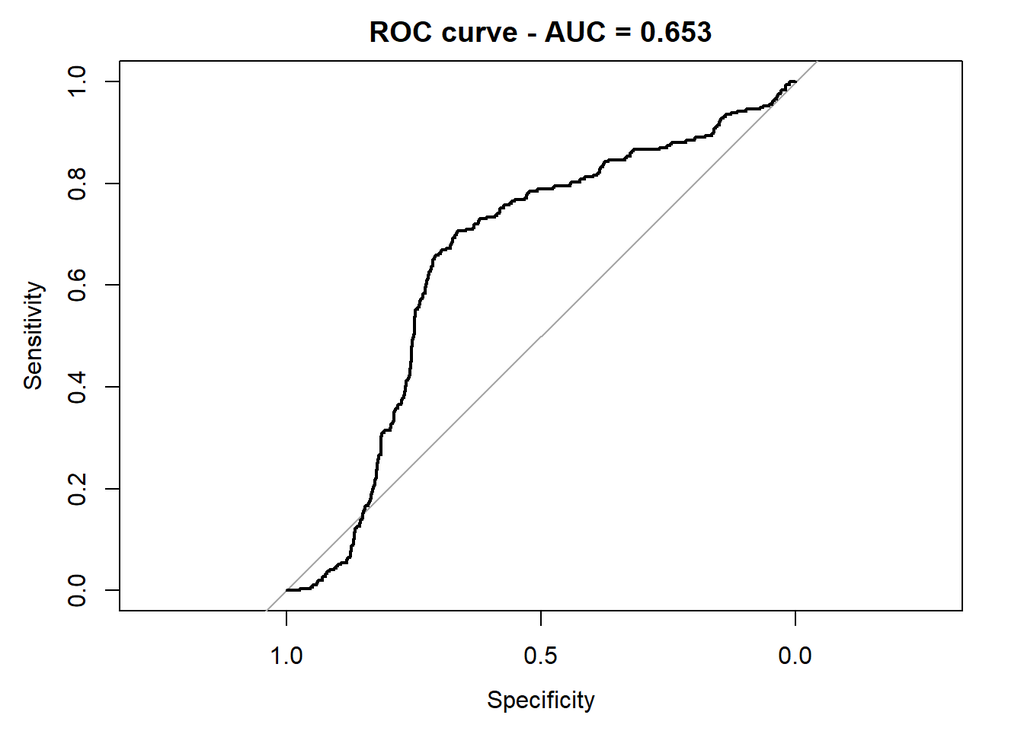

```r
plot(
  auc_obj,
  main = paste("ROC curve - AUC =", round(auc(auc_obj), 3))
)
```

AUC muy modesto, levemente mejor que azar, también tiene sentido. Lo ignoramos

### Interprestación

Vamos a ignorar que es un modelo medio malo y vamos a interpretar.

```r
summary(rsf_fit)
```

```
##
## Call:
## glm(formula = used_num ~ dist_costa_m, family = binomial(link = "logit"),
##     data = rsf_mod_dat, weights = w)
##
## Coefficients:
##                Estimate Std. Error z value Pr(>|z|)
## (Intercept)  -3.7568878  0.1089178 -34.493  < 2e-16 ***
## dist_costa_m -0.0005698  0.0000711  -8.013 1.12e-15 ***
## ---
## Signif. codes:  0 '***' 0.001 '**' 0.01 '*' 0.05 '.' 0.1 ' ' 1
##
## (Dispersion parameter for binomial family taken to be 1)
##
##     Null deviance: 3287.6  on 3222  degrees of freedom
## Residual deviance: 3220.3  on 3221  degrees of freedom
## AIC: 3224.3
##
## Number of Fisher Scoring iterations: 6
```

Eso significa que al aumentar la distancia a la costa, disminuye la selección/uso relativo. Pero como el efecto está expresado por metro, el número parece chico.

Interpretación

```r
exp(coef(rsf_fit)["dist_costa_m"])
```

```
## dist_costa_m
##    0.9994304
```

Más util. A 100 m

```r
exp(coef(rsf_fit)["dist_costa_m"] * 100)
```

```
## dist_costa_m
##    0.9446169
```

```r
1 - (exp(-0.0006293 * 100))
```

```
## [1] 0.0609908
```

A 1 km

```r
1 - (exp(coef(rsf_fit)["dist_costa_m"] * 1000))
```

```
## dist_costa_m
##     0.434338
```

Predichos

```r
pred_dat <- data.frame(
  dist_costa_m = seq(
    min(rsf_mod_dat$dist_costa_m, na.rm = TRUE),
    max(rsf_mod_dat$dist_costa_m, na.rm = TRUE),
    length.out = 300))

pred_link <- predict(
  rsf_fit,
  newdata = pred_dat,
  type = "link",
  se.fit = TRUE)

pred_dat <- pred_dat |>
  mutate(
    eta = pred_link$fit,
    se = pred_link$se.fit,
    eta_lwr = eta - 1.96 * se,
    eta_upr = eta + 1.96 * se,

    rsf = exp(eta),
    rsf_lwr = exp(eta_lwr),
    rsf_upr = exp(eta_upr),

    rsf_rel = rsf / max(rsf, na.rm = TRUE),
    rsf_rel_lwr = rsf_lwr / max(rsf, na.rm = TRUE),
    rsf_rel_upr = rsf_upr / max(rsf, na.rm = TRUE)
  )
```

```r
ggplot(pred_dat, aes(x = dist_costa_m, y = rsf_rel)) +
  geom_ribbon(
    aes(ymin = rsf_rel_lwr, ymax = rsf_rel_upr),
    fill = "goldenrod1",
    alpha = 0.35) +
  geom_line(
    color = "darkorange4",
    linewidth = 1.25) +
  theme_classic(base_size = 13) +
  labs(
    x = "Distancia a la costa (m)",
    y = "Fuerza relativa de selección") +
  theme(
    axis.title = element_text(size = 12),
    axis.text = element_text(size = 11))
```

[figure not shown]

Clarisimo.. una opción razonable hubiese sido modelar la distancia como cuadrática.. pero tenemos buena información así.

### Extrapolación

Algo que está bueno es extender las predicciones del modelo en el espacio. Claramente es algo muy ambicioso considerando lo poco que modelamos, pero sirve a modo de ejemplo.

```r
res_m <- 50  # lo podemos variar según detalle/peso computacional

r_base <- rast(
  ext(
    as.numeric(bb_zoom["xmin"]),
    as.numeric(bb_zoom["xmax"]),
    as.numeric(bb_zoom["ymin"]),
    as.numeric(bb_zoom["ymax"])),
  resolution = res_m,
  crs = st_crs(finlandia_crop)$wkt)

costa_vect <- vect(costa_finlandia)

costa_r <- rasterize(
  costa_vect,
  r_base,
  field = 1)

dist_costa_r <- distance(costa_r)
names(dist_costa_r) <- "dist_costa_m"
```

Enmascaramos al recorte de Finlandia que hicimos antes

```r
fin_crop_vect <- vect(finlandia_crop)

dist_costa_crop <- dist_costa_r |>
  crop(fin_crop_vect) |>
  mask(fin_crop_vect)

names(dist_costa_crop) <- "dist_costa_m"
```

Predecimos seleccion espacial

```r
rsf_pred <- predict(
  dist_costa_crop,
  rsf_fit,
  type = "response")

names(rsf_pred) <- "selection_prob"
```

Eso devuelve la predicción en escala logística. Para RSF usada/disponible, yo la llamaría probabilidad relativa de selección o índice relativo de selección, no probabilidad absoluta.

Si querés una escala relativa entre 0 y 1, donde 1 sea el máximo dentro del mapa:

```r
rsf_rel <- rsf_pred / global(rsf_pred, "max", na.rm = TRUE)[1, 1]
names(rsf_rel) <- "relative_selection"
```

```r
rsf_map_df <- as.data.frame(rsf_rel, xy = TRUE, na.rm = TRUE)
names(rsf_map_df)[3] <- "relative_selection"
```

```r
ggplot() +
  geom_raster(
    data = rsf_map_df,
    aes(x = x, y = y, fill = relative_selection)
  ) +
  geom_sf(
    data = finlandia_crop,
    fill = NA,
    color = "white",
    linewidth = 0.6
  ) +
  geom_sf(
    data = finlandia_crop,
    fill = NA,
    color = "grey10",
    linewidth = 0.25
  ) +
  geom_sf(
    data = costa_crop,
    color = "grey5",
    linewidth = 0.25
  ) +
  coord_sf(
    xlim = c(as.numeric(bb_zoom["xmin"]), as.numeric(bb_zoom["xmax"])),
    ylim = c(as.numeric(bb_zoom["ymin"]), as.numeric(bb_zoom["ymax"])),
    crs = st_crs(finlandia_crop),
    expand = FALSE
  ) +
  scale_fill_viridis_c(
    option = "magma",
    direction = -1,
    limits = c(0, 1),
    name = "Fuerza relativa\nde selección"
  ) +
  labs(
    title = "Predicción espacial de selección",
    subtitle = paste("RSF —", unique(pepe_res$id)[1]),
    x = "Este (m)",
    y = "Norte (m)"
  ) +
  theme_void(base_size = 13) +
  theme(
    plot.title = element_text(face = "bold", size = 15),
    plot.subtitle = element_text(size = 11),
    legend.position = "right",
    legend.title = element_text(size = 10),
    legend.text = element_text(size = 9),
    panel.background = element_rect(fill = "#dceff7", color = NA),
    plot.background = element_rect(fill = "white", color = NA),
    plot.margin = margin(10, 10, 10, 10)
  )
```

[figure not shown]

Este mapa representa la selección del paisaje para nuestro perro unicamente basandonos en la distancia a la costa. Lo interesante es meter más variables (inclusive con interacciones complejas entre sí) y la probabilidad espacial de selección se empieza a tornar un poco más interesante. Además, debberíamos repetir todo este proceso para todos los perros.